# All Weather Strategy v1.2: Graduate-Level Tutorial

### 5.3 Adaptive Rebalancing Logic

**Function**: `should_rebalance(current_prices, target_weights)`

**Implementation** (from `src/strategy.py:72-104`):

```python
# Simulate drift-based rebalancing decision
print("Adaptive Rebalancing Simulation:")
print("=" * 70)

# Simulate different drift scenarios
thresholds = [0.00, 0.02, 0.05, 0.10, 0.15]
target_weights = dict(zip(recent_returns.columns, weights_v12))

# Calculate current weights after shock (simplified)
# In reality, this uses Portfolio.get_weights()
# Simulate 10% return on one asset
returns_shock = {asset: 0.0 for asset in recent_returns.columns}
returns_shock['510300.SH'] = 0.10  # 10% increase

# Calculate new weights after shock
weighted_returns = {
    asset: target_weights[asset] * (1 + returns_shock[asset])
    for asset in recent_returns.columns
}
total = sum(weighted_returns.values())

current_weights = {
    asset: weighted_returns[asset] / total
    for asset in recent_returns.columns
}

# Calculate drift
drifts = {asset: abs(current_weights[asset] - target_weights[asset])
          for asset in recent_returns.columns}
max_drift = max(drifts.values())

print(f"\nScenario: 10% price increase in 510300.SH")
print(f"\nWeight Drift by Asset:")
drift_df = pd.DataFrame({
    'Target (%)': [target_weights[a] * 100 for a in recent_returns.columns],
    'Current (%)': [current_weights[a] * 100 for a in recent_returns.columns],
    'Drift (%)': [drifts[a] * 100 for a in recent_returns.columns]
}, index=recent_returns.columns)
print(drift_df.to_string())

print(f"\nMaximum Drift: {max_drift:.2%}")
print(f"\nRebalancing Decision by Threshold:")
for threshold in thresholds:
    decision = "REBALANCE" if max_drift > threshold else "SKIP"
    print(f"  Threshold {threshold:.0%}: {decision}")
```

```
Adaptive Rebalancing Simulation:
======================================================================

Scenario: 10% price increase in 510300.SH

Weight Drift by Asset:
           Target (%)  Current (%)  Drift (%)
510300.SH   11.260276    12.248384   0.988107
510500.SH    8.648703     8.552400   0.096302
513500.SH    9.085807     8.984637   0.101170
511260.SH   42.107154    41.638295   0.468859
518880.SH   12.893557    12.749988   0.143568
000066.SH    8.386082     8.292704   0.093378
513100.SH    7.618421     7.533591   0.084830

Maximum Drift: 0.99%

Rebalancing Decision by Threshold:
  Threshold 0%: REBALANCE
  Threshold 2%: SKIP
  Threshold 5%: SKIP
  Threshold 10%: SKIP
  Threshold 15%: SKIP
```

## 6. Full Backtest: 2018-2026

### 6.1 Strategy Configuration

**v1.2 Parameters**:

- **Initial Capital**: ¥1,000,000
- **Rebalance Frequency**: Weekly (every Monday)
- **Lookback Window**: 252 trading days (≈1 year)
- **Commission Rate**: 0.03% per trade
- **Drift Threshold**: 5% (adaptive rebalancing)
- **Covariance Estimator**: Ledoit-Wolf shrinkage
- **Constraints**: None (pure risk parity)

```python
# Initialize v1.2 strategy
strategy = AllWeatherV1(
    prices=prices,
    initial_capital=1_000_000,
    rebalance_freq='W-MON',
    lookback=252,
    commission_rate=0.0003,
    rebalance_threshold=0.05,  # 5% drift threshold
    use_shrinkage=True         # Ledoit-Wolf shrinkage
)

print("All Weather Strategy v1.2 Configuration:")
print("=" * 70)
print(f"Initial Capital: ¥{strategy.initial_capital:,.0f}")
print(f"Rebalance Frequency: {strategy.rebalance_freq}")
print(f"Lookback Window: {strategy.lookback} days")
print(f"Commission Rate: {strategy.commission_rate:.2%}")
print(f"Drift Threshold: {strategy.rebalance_threshold:.0%}")
print(f"Use Shrinkage: {strategy.use_shrinkage}")
print(f"Target Volatility: {strategy.target_volatility if strategy.target_volatility else 'None (unconstrained)'}")
```

```
All Weather Strategy v1.2 Configuration:
======================================================================
Initial Capital: ¥1,000,000
Rebalance Frequency: W-MON
Lookback Window: 252 days
Commission Rate: 0.03%
Drift Threshold: 5%
Use Shrinkage: True
Target Volatility: None (unconstrained)
```

### 6.2 Run Backtest

**Simulation Process**:

1. For each trading day from 2018-01-01 to 2026-01-28:
   - Update portfolio value with current prices
   - If it's a Monday (rebalance date):
     - Calculate 252-day returns
     - Estimate covariance with Ledoit-Wolf shrinkage
     - Optimize weights for equal risk contribution
     - Calculate weight drift from last target
     - If drift > 5%, execute rebalance (with commissions)
     - Else, skip rebalance
   - Record equity, returns, weights
2. Calculate performance metrics
3. Generate diagnostics and visualizations

```python
# Run backtest
print("\n" + "=" * 70)
print("RUNNING BACKTEST")
print("=" * 70)

results = strategy.run_backtest(
    start_date='2018-01-01',
    end_date='2026-01-28',
    verbose=True
)
```

```
======================================================================
RUNNING BACKTEST
======================================================================
Backtest: 2018-01-01 to 2026-01-28
Rebalances: 422
[2018-01-15] Rebalanced (drift=6.54%)
[2018-01-22] Rebalanced (drift=5.69%)
[2018-01-29] Rebalanced (drift=5.62%)
[2018-02-05] Rebalanced (drift=5.72%)
[2018-02-12] Rebalanced (drift=5.65%)
[2018-02-26] Rebalanced (drift=6.04%)
[2018-03-05] Rebalanced (drift=5.98%)
[2018-03-12] Rebalanced (drift=6.15%)
[2018-03-19] Rebalanced (drift=6.08%)
[2018-03-26] Rebalanced (drift=5.91%)
[2018-04-02] Rebalanced (drift=5.80%)
[2018-04-09] Rebalanced (drift=5.77%)
[2018-04-16] Rebalanced (drift=5.74%)
[2018-04-23] Rebalanced (drift=5.71%)
[2018-05-07] Rebalanced (drift=5.64%)
[2018-05-14] Rebalanced (drift=5.69%)
[2018-05-21] Rebalanced (drift=5.63%)
[2018-05-28] Rebalanced (drift=5.62%)
[2018-06-04] Rebalanced (drift=5.61%)
[2018-06-11] Rebalanced (drift=5.57%)
[2018-06-25] Rebalanced (drift=5.54%)
[2018-07-02] Rebalanced (drift=5.51%)
[2018-07-09] Rebalanced (drift=5.51%)
[2018-07-16] Rebalanced (drift=5.47%)
[2018-07-23] Rebalanced (drift=5.35%)
[2018-07-30] Rebalanced (drift=5.37%)
[2018-08-06] Rebalanced (drift=5.42%)
[2018-08-13] Rebalanced (drift=5.38%)
[2018-08-20] Rebalanced (drift=5.36%)
[2018-08-27] Rebalanced (drift=5.41%)
[2018-09-03] Rebalanced (drift=5.60%)
[2018-09-10] Rebalanced (drift=5.59%)
[2018-09-17] Rebalanced (drift=5.57%)
[2018-10-08] Rebalanced (drift=5.60%)
[2018-10-15] Rebalanced (drift=5.51%)
```

[output cut: 340 more lines]

```
[2025-12-08] Rebalanced (drift=8.04%)
[2025-12-15] Rebalanced (drift=7.81%)
[2025-12-22] Rebalanced (drift=8.03%)
[2025-12-29] Rebalanced (drift=8.34%)
[2026-01-05] Rebalanced (drift=8.58%)
[2026-01-12] Rebalanced (drift=9.26%)
[2026-01-19] Rebalanced (drift=8.44%)
[2026-01-26] Rebalanced (drift=8.53%)

============================================================
Backtest Complete!
============================================================
Rebalances executed: 175
Rebalances skipped: 209
Efficiency: 50.5%
```

### 6.3 Performance Summary

```python
# Extract results
equity_curve = results['equity_curve']
returns_series = results['returns']
weights_history = results['weights_history']
metrics = results['metrics']

# Print comprehensive metrics
print("\n" + "=" * 70)
print("PERFORMANCE SUMMARY (2018-2026)")
print("=" * 70)

print(f"\nReturn Metrics:")
print(f"  Total Return: {results['total_return']:.2%}")
print(f"  Annual Return: {metrics['annual_return']:.2%}")
print(f"  Final Value: ¥{results['final_value']:,.0f}")
print(f"  Profit: ¥{results['final_value'] - strategy.initial_capital:,.0f}")

print(f"\nRisk Metrics:")
print(f"  Annual Volatility: {metrics['annual_volatility']:.2%}")
print(f"  Max Drawdown: {metrics['max_drawdown']:.2%}")
print(f"  Tail Ratio: {metrics['tail_ratio']:.2%}")
print(f"  Value at Risk (5%): {metrics['var_95']:.2%}")
print(f"  CVaR (5%): {metrics['cvar_95']:.2%}")

print(f"\nRisk-Adjusted Metrics:")
print(f"  Sharpe Ratio: {metrics['sharpe_ratio']:.2f}")
print(f"  Sortino Ratio: {metrics['sortino_ratio']:.2f}")
print(f"  Calmar Ratio: {metrics['calmar_ratio']:.2f}")

print(f"\nTrading Activity:")
print(f"  Rebalances Executed: {results['rebalances_executed']}")
print(f"  Rebalances Skipped: {results['rebalances_skipped']}")
print(f"  Rebalance Efficiency: {results['rebalance_efficiency']:.1%}")
print(f"  Total Trades: {len(strategy.portfolio.trade_history)}")

print(f"\nDistribution Metrics:")
print(f"  Skewness: {metrics['skewness']:.3f}")
print(f"  Kurtosis: {metrics['kurtosis']:.3f}")
```

```
======================================================================
PERFORMANCE SUMMARY (2018-2026)
======================================================================

Return Metrics:
  Total Return: 119.15%
  Annual Return: 10.62%
  Final Value: ¥2,191,500
  Profit: ¥1,191,500

Risk Metrics:
  Annual Volatility: 5.67%
  Max Drawdown: -7.68%
  Tail Ratio: 111.43%
  Value at Risk (5%): -0.49%
  CVaR (5%): -0.83%

Risk-Adjusted Metrics:
  Sharpe Ratio: 1.34
  Sortino Ratio: 1.73
  Calmar Ratio: 1.38

Trading Activity:
  Rebalances Executed: 175
  Rebalances Skipped: 209
  Rebalance Efficiency: 50.5%
  Total Trades: 811

Distribution Metrics:
  Skewness: -0.423
  Kurtosis: 8.739
```

## 7. Diagnostic Analysis

### 7.1 Equity Curve and Drawdowns

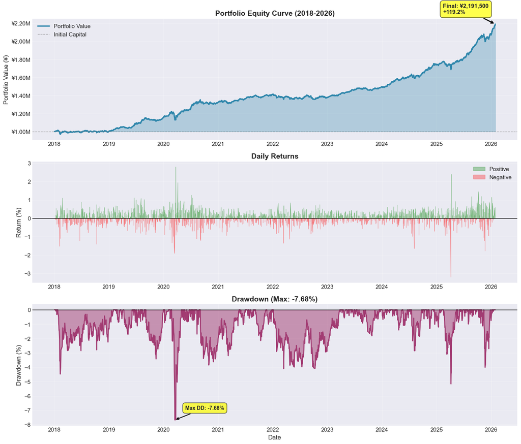

```python
# Calculate drawdown series
running_max = equity_curve.expanding().max()
drawdown = (equity_curve - running_max) / running_max

# Create visualization
fig, (ax1, ax2, ax3) = plt.subplots(3, 1, figsize=(14, 12))

# Equity curve
ax1.plot(equity_curve.index, equity_curve.values, linewidth=2.5, color='#2E86AB', label='Portfolio Value')
ax1.fill_between(equity_curve.index, strategy.initial_capital, equity_curve.values,
                 alpha=0.3, color='#2E86AB')
ax1.axhline(y=strategy.initial_capital, color='gray', linestyle='--',
           linewidth=1, alpha=0.7, label='Initial Capital')
ax1.set_title('Portfolio Equity Curve (2018-2026)', fontsize=14, fontweight='bold')
ax1.set_ylabel('Portfolio Value (¥)', fontsize=12)
ax1.yaxis.set_major_formatter(plt.FuncFormatter(lambda x, p: f'¥{x/1e6:.2f}M'))
ax1.legend(loc='upper left', fontsize=11)
ax1.grid(True, alpha=0.3)

# Annotate final value
ax1.annotate(f'Final: ¥{results["final_value"]:,.0f}\n+{results["total_return"]:.1%}',
            xy=(equity_curve.index[-1], equity_curve.iloc[-1]),
            xytext=(-100, 20), textcoords='offset points',
            fontsize=11, fontweight='bold',
            bbox=dict(boxstyle='round,pad=0.5', facecolor='yellow', alpha=0.7),
            arrowprops=dict(arrowstyle='->', connectionstyle='arc3,rad=0', lw=2))

# Daily returns
ax2.fill_between(returns_series.index, 0, returns_series.values * 100,
                where=(returns_series > 0), color='green', alpha=0.3, label='Positive')
ax2.fill_between(returns_series.index, 0, returns_series.values * 100,
                where=(returns_series <= 0), color='red', alpha=0.3, label='Negative')
ax2.axhline(y=0, color='black', linewidth=1)
ax2.set_title('Daily Returns', fontsize=14, fontweight='bold')
ax2.set_ylabel('Return (%)', fontsize=12)
ax2.legend(loc='upper right', fontsize=11)
ax2.grid(True, alpha=0.3)

# Drawdown
ax3.fill_between(drawdown.index, 0, drawdown.values * 100,
                color='#A23B72', alpha=0.5)
ax3.plot(drawdown.index, drawdown.values * 100, linewidth=2, color='#A23B72')
ax3.axhline(y=0, color='black', linewidth=1)
ax3.set_title(f'Drawdown (Max: {metrics["max_drawdown"]:.2%})', fontsize=14, fontweight='bold')
ax3.set_ylabel('Drawdown (%)', fontsize=12)
ax3.set_xlabel('Date', fontsize=12)
ax3.grid(True, alpha=0.3)

# Annotate max drawdown
max_dd_idx = drawdown.idxmin()
max_dd_val = drawdown.min()
ax3.annotate(f'Max DD: {max_dd_val:.2%}',
            xy=(max_dd_idx, max_dd_val * 100),
            xytext=(20, 20), textcoords='offset points',
            fontsize=10, fontweight='bold',
            bbox=dict(boxstyle='round,pad=0.5', facecolor='yellow', alpha=0.7),
            arrowprops=dict(arrowstyle='->', lw=1.5))

plt.tight_layout()
plt.show()
```

### 7.2 Weight Evolution Over Time

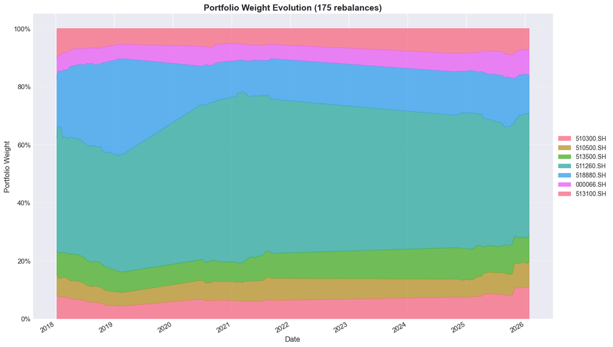

```
Weight Statistics:
======================================================================
           Mean (%)  Std (%)   Min (%)   Max (%)  Last (%)
510300.SH  6.991310 1.548626  4.325402 10.998268 10.998268
510500.SH  6.586653 0.922336  4.645299  8.594631  8.424323
513500.SH  8.604543 1.232021  6.553386 10.983472  8.956441
511260.SH 46.669770 6.773726 38.647690 59.108327 42.390151
518880.SH 17.876889 6.686370 10.848331 33.361343 13.186080
000066.SH  6.352990 1.110268  4.934390  9.104920  8.553177
513100.SH  6.917844 1.239887  5.100962 10.661348  7.491560
```

```python
# Plot weight evolution
fig, ax = plt.subplots(figsize=(14, 8))

if not weights_history.empty:
    # Stacked area chart
    weights_history.plot.area(stacked=True, ax=ax, alpha=0.8, linewidth=0.5)

    ax.set_title(f'Portfolio Weight Evolution ({results["rebalances_executed"]} rebalances)',
                fontsize=14, fontweight='bold')
    ax.set_ylabel('Portfolio Weight', fontsize=12)
    ax.set_xlabel('Date', fontsize=12)
    ax.yaxis.set_major_formatter(plt.FuncFormatter(lambda x, p: f'{x:.0%}'))
    ax.legend(loc='center left', bbox_to_anchor=(1, 0.5), fontsize=10)
    ax.grid(True, alpha=0.3, axis='y')

    plt.tight_layout()
    plt.show()

    # Weight statistics
    print("\nWeight Statistics:")
    print("=" * 70)
    weight_stats = pd.DataFrame({
        'Mean (%)': weights_history.mean() * 100,
        'Std (%)': weights_history.std() * 100,
        'Min (%)': weights_history.min() * 100,
        'Max (%)': weights_history.max() * 100,
        'Last (%)': weights_history.iloc[-1] * 100
    })
    print(weight_stats.to_string())
else:
    print("No rebalancing history available")
```